# Classifying Weight Lifting Form from Wearable Sensors

Coursera - Practical Machine Learning Course Project

### Synopsis

A random forest model is created to classify weight lifting forms from wearable sensor input.

### Data details

Here, we examine how well you can predict the version of weigh lifting that the test subject is engaging in, based on various sensors that the subject is wearing and sensors on the exercise equipment. The data comes from [Groupware@LES](http://groupware.les.inf.puc-rio.br/har) and was used in the following research article:

Velloso, E.; Bulling, A.; Gellersen, H.; Ugulino, W.; Fuks, H. Qualitative Activity Recognition of Weight Lifting Exercises. Proceedings of 4th International Conference in Cooperation with SIGCHI (Augmented Human ’13) . Stuttgart, Germany: ACM SIGCHI, 2013.

These are the possible outcomes or versions of weight lifting we are trying to predict:

| classe | which version of weight lifting |
| --- | --- |
| A | exactly according to the specification |
| B | throwing the elbows to the front |
| C | lifting the dumbbell only halfway |
| D | lowering the dumbbell only halfway |
| E | throwing the hips to the front |

### Data Processing

Initial loading of a few lines from the training data showed an abundance of NA, !DIV/0, and empty string values. So when loading the data, R is explicitly instructed to treat all three as NA. Note that the string values were separated by \" , so those were removed.

```r
library(caret)
library(randomForest)
library(tree)
library(rpart.plot)
set.seed(1290)

train_url <- 'https://d396qusza40orc.cloudfront.net/predmachlearn/pml-training.csv'
test_url <- 'https://d396qusza40orc.cloudfront.net/predmachlearn/pml-testing.csv'

# download the data and document when it was done
## conditional create data folder
if(!file.exists("data")) {
  dir.create("data")

  download.file(train_url, destfile = "./data/pml-training.csv", method='wget')
  fileConn <- file("./data/pml-training_dateDL.txt")
  dateDL <- date()
  writeLines(dateDL, fileConn)
  close(fileConn)

  download.file(test_url, destfile = "./data/pml-testing.csv", method = 'wget')
  fileConn <- file("./data/pml-testing_dateDL.txt")
  dateDL <- date()
  writeLines(dateDL, fileConn)
  close(fileConn)
}

training <- read.csv("./data/pml-training.csv", header = TRUE
                     , na.strings = c("NA", "#DIV/0!", "")
                     , quote ="\"")
testing <- read.csv("./data/pml-testing.csv", header = TRUE
                     , na.strings = c("NA", "#DIV/0!", "")
                     , quote ="\"")
```

Then we subdivide the training set so we can make an estimate of the out-of-sample error.

```r
inTrain <- createDataPartition(y=training$classe, p=0.7, list=FALSE)
trainsub <- training[inTrain,]
testsub <- training[-inTrain, ]
```

Earlier we noted that there were a number of NA values. How many of the variables are missing the majority of their values (are NA)? Using a relatively high bar of 90% NA’s, it turns out there are a substantial number of variables that are mostly empty.

```r
nafunc <- function(x) sum(is.na(x))
sum_nas <- sapply(trainsub, nafunc)  # No. of rows in each col with NA
```

Those variables, being empty, have very little information, so they are removed from the analysis.

```r
trainRows <- dim(trainsub)[1]
few_nas <- !(sum_nas >= 0.9*trainRows)   # if there aren't too many NAs, TRUE
dim(trainsub)[2]-sum(few_nas) # removed this many variables
```

```
## [1] 100
```

```r
sum(few_nas) # kept this many variables
```

```
## [1] 60
```

Consider as well the information given by the column names. By visual inspection, some of these, such as the subject’s name, should not have any significance on the outcome. So those are also removed

```r
names(trainsub)[1:7]
```

```
## [1] "X"                    "user_name"            "raw_timestamp_part_1"
## [4] "raw_timestamp_part_2" "cvtd_timestamp"       "new_window"
## [7] "num_window"
```

```r
maybe_useful <- c(rep(TRUE, times=length(trainsub)))
maybe_useful[c(1,2,3,4,5,6,7)] <- FALSE

keepvar_mask <- maybe_useful & few_nas
usefulVars <- sum(keepvar_mask)

trainsub <- trainsub[ ,keepvar_mask]
testsub <- testsub[ ,keepvar_mask]
```

This leaves us with 53 columns in our data (including one for the outcome).

### Model Construction

To classify the exercise type, let’s consider grouping the data using a collection of classification trees, built using the randomForest function. Note that the randomForest algorithm uses cross-validation to build the forest, as detailed in [Leo Breiman’s site](http://www.stat.berkeley.edu/~breiman/RandomForests/cc_home.htm#workings).  
When individual trees are constructed, some cases are left of training and are run down that tree to calculated an out-of-bag error estimate. Using this measure, we can optimize *mtry*, the number of predictors sampled for spliting at each node. The caret [*train* function](http://topepo.github.io/caret/training.html) will do this automatically using the “one standard error rule”, but since the caret train function can be very memory-intensive and subsequently very slow, let us optimize for *mtry* separately and then call *randomForest*.

```r
rf_tune <- tuneRF(trainsub[,1:(length(trainsub)-1)], trainsub$classe
                 , doBest=FALSE
                 , trace=FALSE
                 )
```

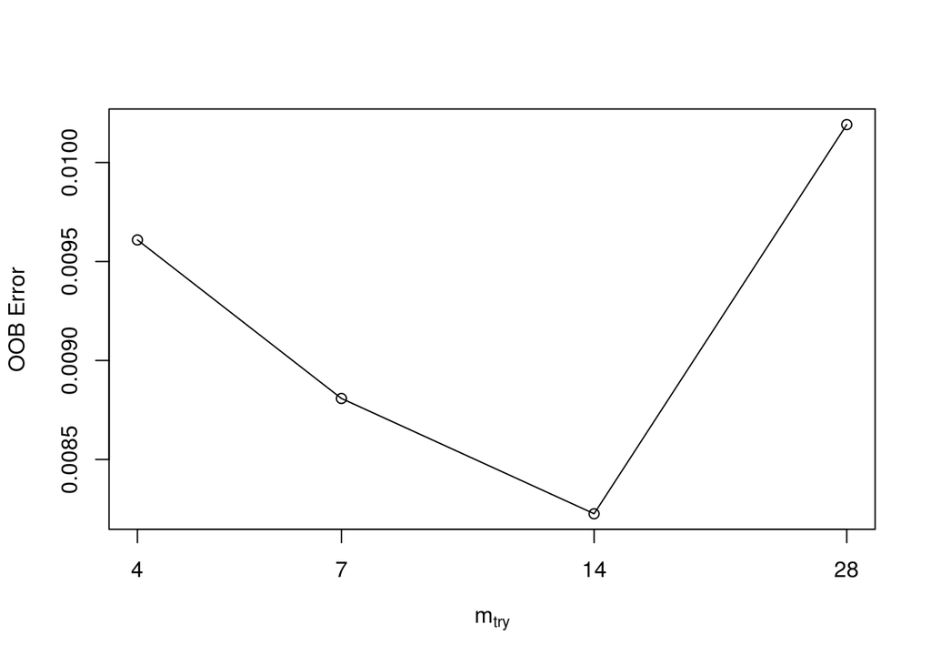

```r
mtry_tuned <- which.min(rf_tune)
```

```r
rf_fit6 <- randomForest(classe ~ . , data=trainsub
                        , mtry=mtry_tuned
                        , ntree=501)
rf_fit6
```

```
##
## Call:
##  randomForest(formula = classe ~ ., data = trainsub, mtry = mtry_tuned,      ntree = 501)
##                Type of random forest: classification
##                      Number of trees: 501
## No. of variables tried at each split: 7
##
##         OOB estimate of  error rate: 0.55%
## Confusion matrix:
##      A    B    C    D    E class.error
## A 3903    3    0    0    0    0.000768
## B   18 2631    9    0    0    0.010158
## C    0   11 2381    4    0    0.006260
## D    0    0   23 2227    2    0.011101
## E    0    0    1    5 2519    0.002376
```

### Results

From our random forest model, we can view the importance of the variables. Here’s a list of the top 10 most imporant variables

```r
vars <- rownames(importance(rf_fit6))
impt_vals <- importance(rf_fit6)[1:length(importance(rf_fit6))]
impts <- data.frame('var_name'=vars, 'impt_val'=impt_vals)
impts <- impts[with(impts, order(-impt_val)), ]
head(impts, 10)
```

```
##             var_name impt_val
## 1          roll_belt    891.4
## 3           yaw_belt    611.6
## 41     pitch_forearm    529.2
## 39 magnet_dumbbell_z    525.9
## 2         pitch_belt    498.3
## 38 magnet_dumbbell_y    472.5
## 40      roll_forearm    411.7
## 37 magnet_dumbbell_x    335.9
## 10      accel_belt_z    300.0
## 27     roll_dumbbell    294.6
```

One out-of-sample estimate is the out-of-bag estimate given in the random forest model (roughly, the classification error on the cases that were not used to construct a particular tree). To get a better idea estimate, we apply the model to the subset of the training data that was held back and compare the predicted classes to the actual classes.

```r
pred <- predict(rf_fit6,newdata=testsub)
table(pred, testsub$classe)
```

```
##
## pred    A    B    C    D    E
##    A 1674    7    0    0    0
##    B    0 1129    9    0    0
##    C    0    3 1016    6    3
##    D    0    0    1  957    4
##    E    0    0    0    1 1075
```

```r
oos_err <- sum(!(pred==testsub$classe))/dim(testsub)[1]
# estimate of out of sample error
oos_err
```

```
## [1] 0.005777
```

So a good estimate of the out-of-sample error is 0.0058, or 0.5777%.

Now the model is applied to the test cases given, being careful to apply the preprocessing (in this case, discarding the same variables) as in the training set.

```r
testing <- testing[ ,keepvar_mask]
pred2 <- predict(rf_fit6,newdata=testing)

### submission file script from course website
pml_write_files <- function(x){
    n = length(x)
    for(i in 1:n){
        filename = paste0("results/problem_id_",i,".txt")
        write.table(x[i],file=filename,quote=FALSE,row.names=FALSE,col.names=FALSE)
    }
}

pml_write_files(pred2)
```